# R Notebook

optimism or pessimism

I read lyrics a lot from primary school to university. In my memory, most famous chinese lyrics are about sad stories. Most Chinese artists are very pessimism.

How about american artists? I’m about to find out!

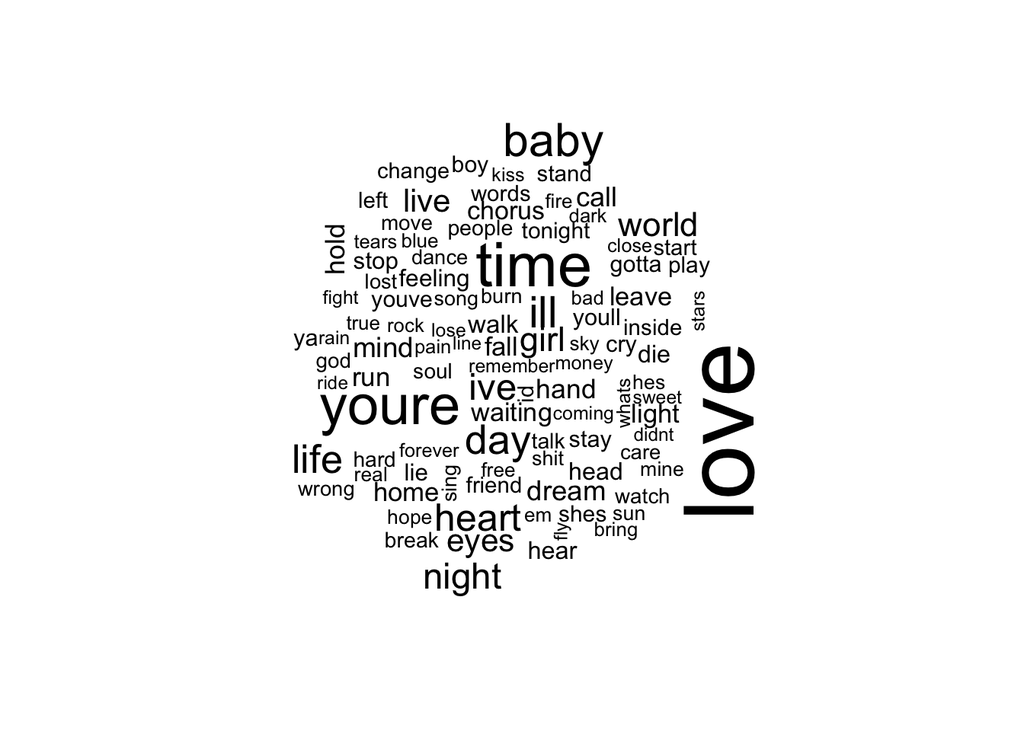

Which word Amercian artists use most

| word | sentiment | n |
| --- | --- | --- |
| love | positive | 194052 |
| fall | negative | 32478 |
| die | negative | 28362 |
| lie | negative | 26504 |
| cry | negative | 25297 |
| break | negative | 21737 |
| hard | negative | 21244 |
| wrong | negative | 19757 |
| lost | negative | 19752 |
| burn | negative | 19383 |

More specific, what kind of words American artists use most

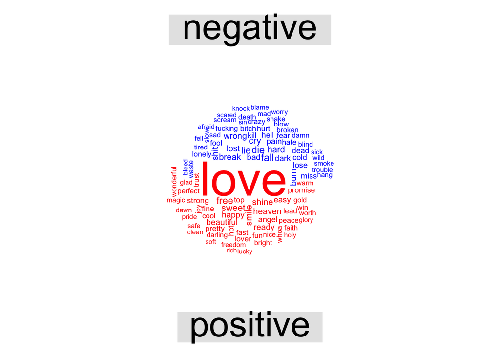

The number of “love” used in the lyrics is quite surprising. Lyrics are full of “love”. Does that mean american artists are truly optimism?

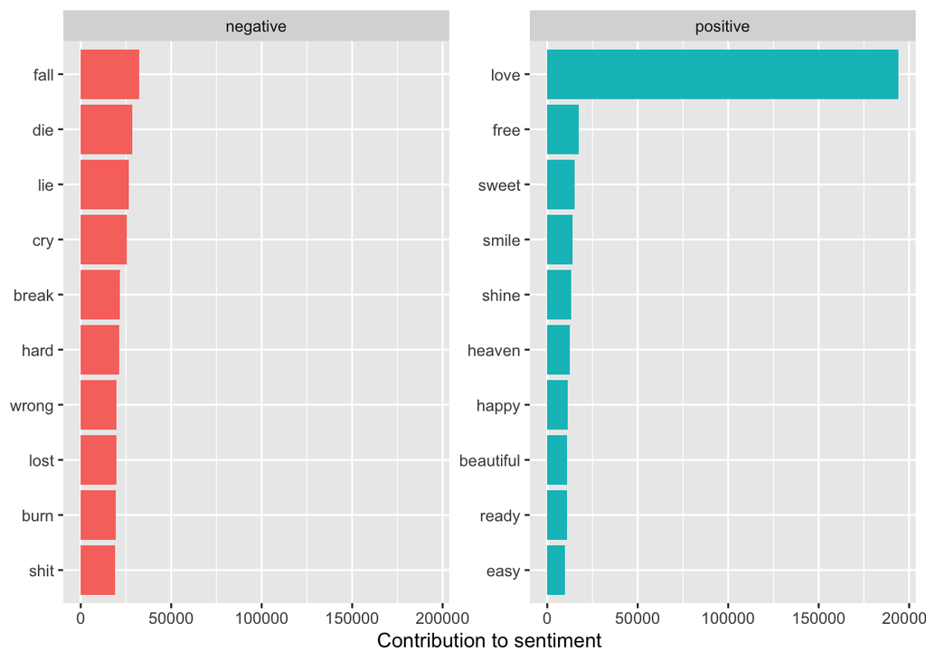

|  | year | negativewords | words.x | ratio.x | positivewords | words.y | ratio.y |
| --- | --- | --- | --- | --- | --- | --- | --- |
| 3 | 1968 | 10 | 40 | 0.25000000 | 1 | 40 | 0.02500000 |
| 4 | 1970 | 713 | 6316 | 0.11288790 | 647 | 6316 | 0.10243825 |
| 5 | 1971 | 792 | 7538 | 0.10506766 | 639 | 7538 | 0.08477050 |
| 6 | 1972 | 795 | 7450 | 0.10671141 | 721 | 7450 | 0.09677852 |
| 7 | 1973 | 1175 | 10853 | 0.10826500 | 1022 | 10853 | 0.09416751 |
| 8 | 1974 | 1069 | 8835 | 0.12099604 | 727 | 8835 | 0.08228636 |
| 9 | 1975 | 512 | 5029 | 0.10180950 | 578 | 5029 | 0.11493339 |
| 10 | 1976 | 275 | 2982 | 0.09221999 | 308 | 2982 | 0.10328638 |
| 11 | 1977 | 1586 | 14694 | 0.10793521 | 1344 | 14694 | 0.09146590 |
| 12 | 1978 | 934 | 8936 | 0.10452104 | 862 | 8936 | 0.09646374 |

[output cut: 38 more lines]

```
## [1] 4
```

```
## [1] 44
```

Op! Surprise! Among 48 years, there is only 4 years that positive words ratio is greater than the negative words ratio! I prefer the ratio here, because there are more lyrics data in the recently year. Ratio is more convinced than just counting the words

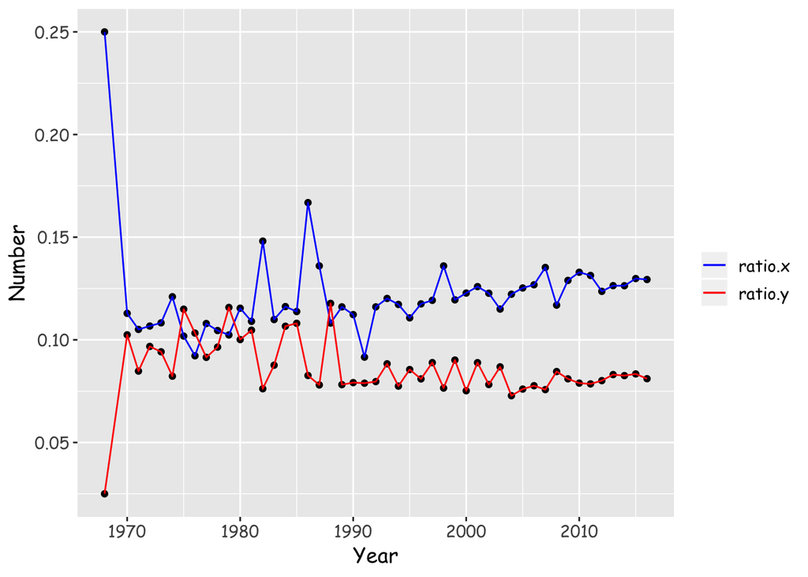

The ratio.x means the negative words/total words; the ratio.y means the positive words/total words. In the graph, it seems that there is a trend that more and more negative words are used in the lyrics. The positive words ratio is kind of stable. Let’s do a linear regression test to see whether there is a linear relationship between negative words and years.

```
##
## Call:
## lm(formula = wordstable$ratio.x ~ wordstable$year)
##
## Residuals:
##       Min        1Q    Median        3Q       Max
## -0.030260 -0.011304 -0.003936  0.003326  0.130204
##
## Coefficients:
##                   Estimate Std. Error t value Pr(>|t|)
## (Intercept)     -5.407e-02  4.829e-01  -0.112    0.911
## wordstable$year  8.835e-05  2.423e-04   0.365    0.717
##
## Residual standard error: 0.02332 on 46 degrees of freedom
## Multiple R-squared:  0.002881,   Adjusted R-squared:  -0.0188
## F-statistic: 0.1329 on 1 and 46 DF,  p-value: 0.7171
```

P value is quite large, which shows there is no significant evidence that negative words ratio has a positive linear relationship with years.

If the world without “LOVE”  
“love” seems like an outliear. The number of “LOVE” used in lyrics is 6 times bigger than the second-used word. What would happen if there is no “LOVE”

without “LOVE” the image is more clear that there are more negative words used in the lyrics.

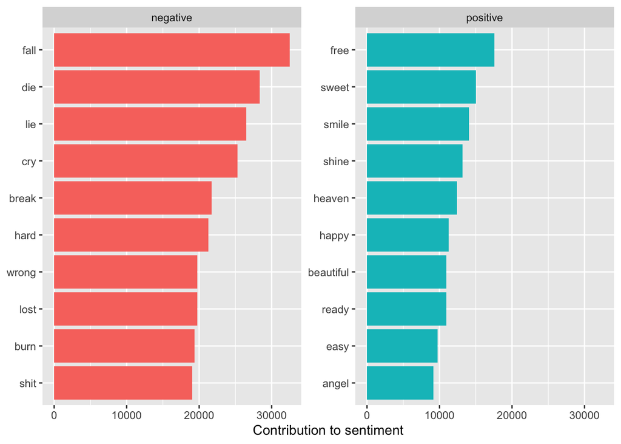

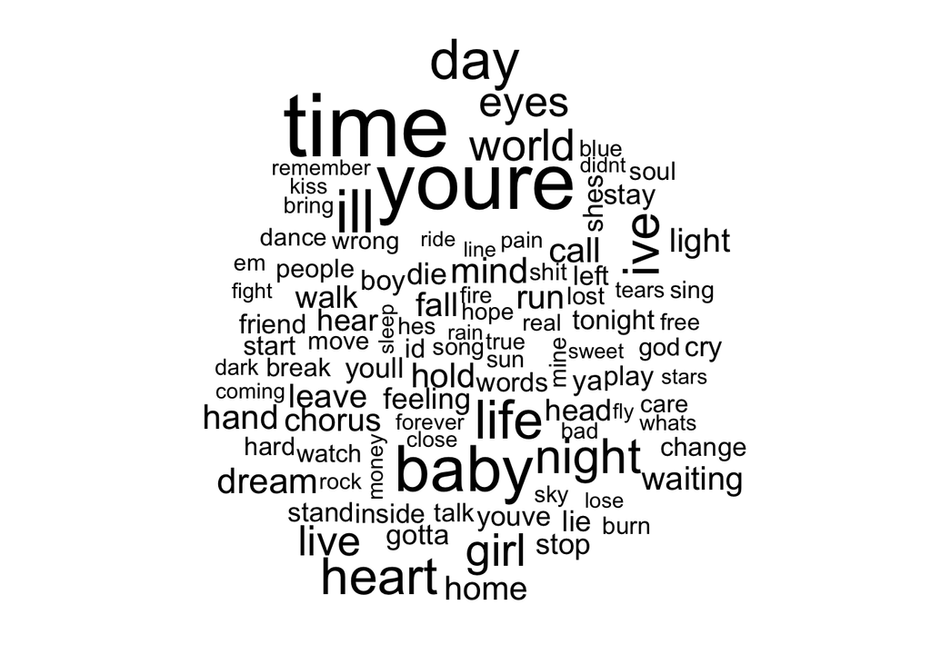

```
## [1] 0
```

```
## [1] 47
```

No doubt, without “LOVE”, Among the 48 years(there is one year that no positive words showed in the lyrics except “LOVE”), there is no year that positive words is greater than nagative words. Nagative words ratio is always greater than positive words ratio.

Conclusions  
American artists use “LOVE” a lot, the frequency is 6 times bigger than the second-used word. It gives us a misconception that most american artists are optimism, however, when we consider the whole positive words ratio VS nagative words ratio, most american artists are pessimism!